# Marovoay–Ankarafantsika: Extended Econometric Analysis

### 3.3 Event study — pre-trend test

```r
panel_es <- panel_twfe_exp |>
  mutate(rel_time = year - TREAT_YEAR)

fit_es <- feols(
  ln_revtot_w ~ i(rel_time, treated_unit, ref = -1) | j5 + year,
  data    = panel_es,
  cluster = ~site_id
)
```

```
NOTES: 9 observations removed because of NA values (LHS: 9).
       644/0 fixed-effect singletons were removed (644 observations).
```

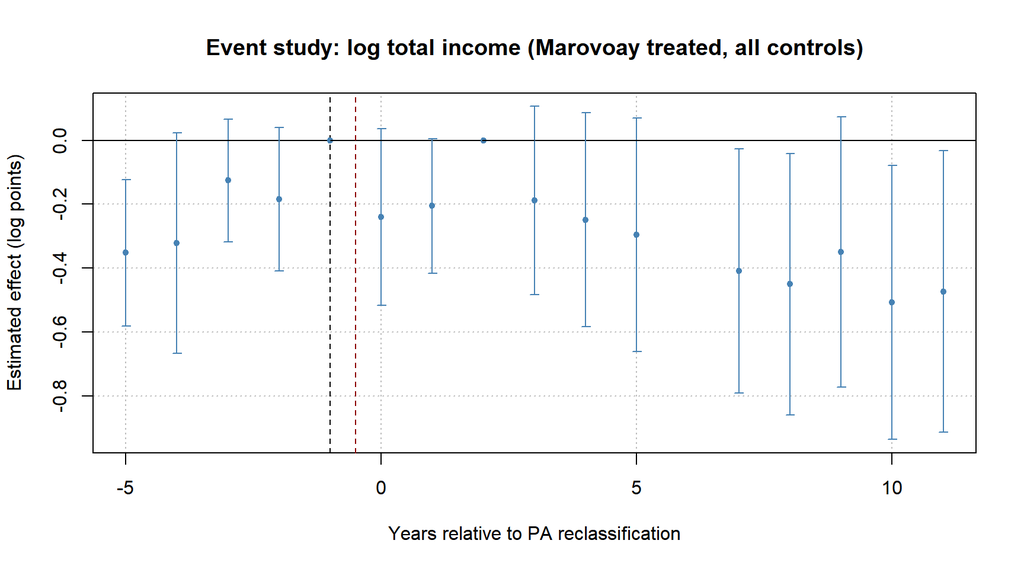

Event-study coefficients for log total income (expanded panel)

```r
iplot(fit_es,
      main   = "Event study: log total income (Marovoay treated, all controls)",
      xlab   = "Years relative to PA reclassification",
      ylab   = "Estimated effect (log points)",
      col    = "steelblue", pt.col = "steelblue")
abline(h = 0, lty = 2)
abline(v = -0.5, lty = 2, col = "darkred")
```

### 3.4 Long-run site-level DiD (1998–2001 baseline vs. 2025)

Because there is no household overlap between the 1998–2001 and 2025 waves, the long-run DiD is estimated at the **site-year aggregate level**. Alaotra sites are included as additional controls for the long-run comparison.

```r
panel_lr_site <- panel_site_expanded |>
  filter((year >= 1998 & year <= 2001) | year == 2025) |>
  mutate(
    post_2025    = as.integer(year == 2025),
    treatment_lr = as.integer(treated_unit & post_2025)
  )

fit_lr_site <- feols(
  ln_revtot_w ~ treatment_lr | site_id + year,
  data    = panel_lr_site,
  cluster = ~site_id
)
```

```
NOTE: 3/0 fixed-effect singletons were removed (3 observations).
```

```r
fit_lr_site_agri <- feols(
  ln_rev_agri_w ~ treatment_lr | site_id + year,
  data    = panel_lr_site,
  cluster = ~site_id
)
```

```
NOTE: 3/0 fixed-effect singletons were removed (3 observations).
```

```r
etable(
  fit_lr_site, fit_lr_site_agri,
  se      = "cluster",
  dict    = c(treatment_lr = "D (treated × 2025)"),
  headers = c("log Total income", "log Agri income"),
  notes   = "Site and year FEs. Clustered SE at site level. Baseline: 1998–2001. Control: Maro (033,034) + Alaotra (211–215)."
)
```

```
                        fit_lr_site fit_lr_site_agri
                   log Total income  log Agri income
Dependent Var.:         ln_revtot_w    ln_rev_agri_w

D (treated × 2025) -0.1552 (0.2149) -0.6234 (0.3803)
Fixed-Effects:     ---------------- ----------------
site_id                         Yes              Yes
year                            Yes              Yes
__________________ ________________ ________________
S.E.: Clustered         by: site_id      by: site_id
Observations                     28               28
R2                          0.99936          0.99044
Within R2                   0.04423          0.06161
---
Signif. codes: 0 '***' 0.001 '**' 0.01 '*' 0.05 '.' 0.1 ' ' 1
```

## 4 Method 2: Callaway–Sant’Anna DiD

With a single treatment cohort, this reduces to a clean 2-group DiD with doubly-robust semiparametric efficiency. We use `panel = FALSE` (repeated cross-section mode) because household composition changes across years.

**2005 is excluded** (the non-representative Marovoay tracking survey would otherwise produce a gap in coverage for group 2003 in 2005).

```r
# ── Marovoay-only CS-DiD ──────────────────────────────────────────────────────
panel_cs_maro <- panel_maro |>
  filter(year <= 2014) |>
  mutate(
    unit_id = as.integer(factor(j5)),
    group   = if_else(treated_unit, as.integer(TREAT_YEAR), 0L)
  )

att_cs_maro <- att_gt(
  yname         = "ln_revtot_w",
  tname         = "year",
  idname        = "unit_id",
  gname         = "group",
  data          = panel_cs_maro,
  control_group = "nevertreated",
  panel         = FALSE,
  est_method    = "dr",
  print_details = FALSE
)

agg_cs_maro    <- aggte(att_cs_maro, type = "simple",  na.rm = TRUE)
agg_cs_dyn     <- aggte(att_cs_maro, type = "dynamic", na.rm = TRUE)

cat("=== CS-DiD: Marovoay only ===\n")
```

```
=== CS-DiD: Marovoay only ===
```

```r
summary(agg_cs_maro)
```

```
Call:
aggte(MP = att_cs_maro, type = "simple", na.rm = TRUE)

Reference: Callaway, Brantly and Pedro H.C. Sant'Anna.  "Difference-in-Differences with Multiple Time Periods." Journal of Econometrics, Vol. 225, No. 2, pp. 200-230, 2021. <https://doi.org/10.1016/j.jeconom.2020.12.001>, <https://arxiv.org/abs/1803.09015>

    ATT    Std. Error     [ 95%  Conf. Int.]
 0.0056         0.057     -0.106      0.1173


---
Signif. codes: `*' confidence band does not cover 0

Control Group:  Never Treated,  Anticipation Periods:  0
Estimation Method:  Doubly Robust
```

```r
# ── Expanded CS-DiD (Marovoay treated + Alaotra controls) ────────────────────
panel_cs_exp <- panel_expanded |>
  filter(year <= 2014) |>
  mutate(
    unit_id = as.integer(factor(j5)),
    group   = if_else(treated_unit, as.integer(TREAT_YEAR), 0L)
  )

att_cs_exp <- att_gt(
  yname         = "ln_revtot_w",
  tname         = "year",
  idname        = "unit_id",
  gname         = "group",
  data          = panel_cs_exp,
  control_group = "nevertreated",
  panel         = FALSE,
  est_method    = "dr",
  print_details = FALSE
)

agg_cs_exp     <- aggte(att_cs_exp, type = "simple",  na.rm = TRUE)
agg_cs_dyn_exp <- aggte(att_cs_exp, type = "dynamic", na.rm = TRUE)

cat("\n=== CS-DiD: Marovoay + Alaotra controls ===\n")
```

```
=== CS-DiD: Marovoay + Alaotra controls ===
```

```r
summary(agg_cs_exp)
```

```
Call:
aggte(MP = att_cs_exp, type = "simple", na.rm = TRUE)

Reference: Callaway, Brantly and Pedro H.C. Sant'Anna.  "Difference-in-Differences with Multiple Time Periods." Journal of Econometrics, Vol. 225, No. 2, pp. 200-230, 2021. <https://doi.org/10.1016/j.jeconom.2020.12.001>, <https://arxiv.org/abs/1803.09015>

     ATT    Std. Error     [ 95%  Conf. Int.]
 -0.4569        0.0493    -0.5534     -0.3603 *


---
Signif. codes: `*' confidence band does not cover 0

Control Group:  Never Treated,  Anticipation Periods:  0
Estimation Method:  Doubly Robust
```

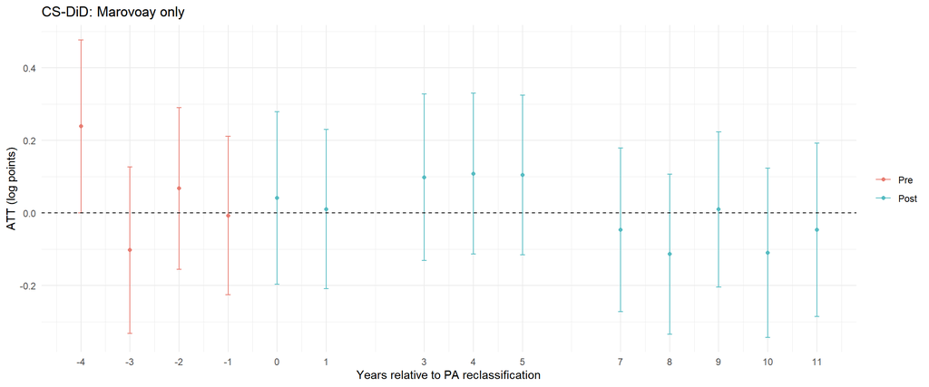

CS-DiD event study: Marovoay only (left) vs. expanded controls (right)

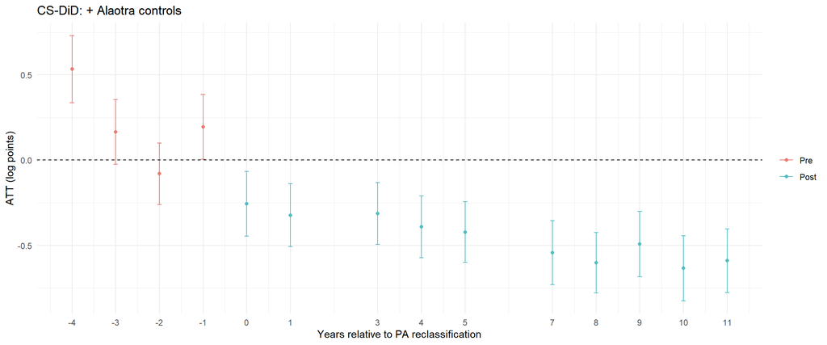

CS-DiD event study: Marovoay only (left) vs. expanded controls (right)

```r
ggdid(agg_cs_dyn,
      title = "CS-DiD: Marovoay only") +
  labs(x = "Years relative to PA reclassification", y = "ATT (log points)") +
  theme_minimal()
ggdid(agg_cs_dyn_exp,
      title = "CS-DiD: + Alaotra controls") +
  labs(x = "Years relative to PA reclassification", y = "ATT (log points)") +
  theme_minimal()
```

## 5 Method 3: Synthetic DiD

```r
outcomes_sdid <- c("ln_revtot_w", "ln_revcou_w", "ln_rev_agri_w", "ln_rev_nonagri_w")

# Helper: build panel.matrices and run SDiD
run_sdid <- function(outcome, data, treated_sites = MARO_TREATED,
                     treat_year = TREAT_YEAR) {
  df_in <- data |>
    rename(unit = site_id, time = year, outcome = all_of(outcome)) |>
    mutate(treated = as.integer(unit %in% treated_sites & time >= treat_year)) |>
    as.data.frame()

  setup <- tryCatch(
    panel.matrices(df_in, unit = "unit", time = "time",
                   outcome = "outcome", treatment = "treated"),
    error = function(e) NULL
  )
  if (is.null(setup)) return(NULL)

  tau <- tryCatch(synthdid_estimate(setup$Y, setup$N0, setup$T0),
                  error = function(e) NULL)
  if (is.null(tau)) return(NULL)

  se <- tryCatch(sqrt(vcov(tau, method = "placebo")), error = function(e) NA_real_)

  list(estimate = tau, se = se, setup = setup, outcome = outcome)
}
```

```r
# Marovoay-only (2 ctrl — SE will be NA)
sdid_maro <- map(outcomes_sdid, ~ run_sdid(.x, panel_site_maro_bal))
names(sdid_maro) <- outcomes_sdid

# Expanded (2 treated + 5 Alaotra ctrl)
sdid_exp <- map(outcomes_sdid, ~ run_sdid(.x, panel_site_expanded_bal))
names(sdid_exp) <- outcomes_sdid

if (!is.null(sdid_exp$ln_revtot_w)) {
  synthdid_plot(sdid_exp$ln_revtot_w$estimate,
                title = "Synthetic DiD: log total income (expanded controls)")
}
```

[output not shown]

```r
extract_sdid <- function(res_list, label) {
  map_dfr(res_list, function(r) {
    if (!is.null(r))
      tibble(Spec = label, Outcome = r$outcome,
             ATT  = as.numeric(r$estimate), SE = r$se)
  })
}

sdid_table <- bind_rows(
  extract_sdid(sdid_maro, "Marovoay only (2 ctrl)"),
  extract_sdid(sdid_exp,  "Expanded (7 ctrl)")
) |>
  mutate(CI_lo = ATT - 1.96 * SE, CI_hi = ATT + 1.96 * SE)

gt(sdid_table) |>
  fmt_number(columns = c(ATT, SE, CI_lo, CI_hi), decimals = 3) |>
  cols_label(Spec = "Specification", Outcome = "Outcome",
             ATT = "ATT", SE = "SE (placebo)", CI_lo = "95% lo", CI_hi = "95% hi") |>
  tab_style(
    style = list(cell_text(weight = "bold"), cell_fill(color = "#DCDCDC")),
    locations = cells_column_labels()
  ) |>
  tab_footnote("SE unavailable when N_controls ≤ N_treated.",
               locations = cells_body(columns = SE,
                                      rows = Spec == "Marovoay only (2 ctrl)"))
```

| Specification | Outcome | ATT | SE (placebo) | 95% lo | 95% hi |
| --- | --- | --- | --- | --- | --- |
| Marovoay only (2 ctrl) | ln_revtot_w | 0.016 | <sup>1</sup> NA | NA | NA |
| Marovoay only (2 ctrl) | ln_revcou_w | 0.045 | <sup>1</sup> NA | NA | NA |
| Marovoay only (2 ctrl) | ln_rev_agri_w | 0.240 | <sup>1</sup> NA | NA | NA |
| Marovoay only (2 ctrl) | ln_rev_nonagri_w | 0.303 | <sup>1</sup> NA | NA | NA |

<sup>1</sup> SE unavailable when N_controls ≤ N_treated.

## 6 Method 4: Augmented Synthetic Control

The Augmented SC (Ben-Michael, Feller & Rothstein 2021; `augsynth` R package) adjusts for poor pre-treatment fit with a ridge-regularised outcome model correction.

```r
# Helper: aggregate treated sites into single unit and run augsynth
run_aug <- function(outcome, data, treated_sites = MARO_TREATED) {
  df_aug <- data |>
    mutate(unit_aug = if_else(site_id %in% treated_sites, "Treated", site_id)) |>
    group_by(unit_aug, year) |>
    summarise(
      val       = mean(get(outcome), na.rm = TRUE),
      treatment = max(treatment),
      .groups   = "drop"
    ) |>
    rename(!!outcome := val)

  form <- as.formula(paste0(outcome, " ~ treatment"))
  safely(augsynth)(form, unit = unit_aug, time = year, data = df_aug,
                   progfunc = "Ridge", scm = TRUE)
}

# Marovoay-only
aug_maro <- map(outcomes_sdid, ~ run_aug(.x, panel_site_maro_bal))
names(aug_maro) <- outcomes_sdid

# Expanded
aug_exp <- map(outcomes_sdid, ~ run_aug(.x, panel_site_expanded_bal))
names(aug_exp) <- outcomes_sdid

if (!is.null(aug_exp$ln_revtot_w$result)) {
  plot(aug_exp$ln_revtot_w$result,
       main = "AugSynth gap: log total income (expanded controls)")
}
```

[output not shown]

```r
extract_aug <- function(res_list, spec_label) {
  imap_dfr(res_list, function(r, outcome_name) {
    if (!is.null(r$result)) {
      s <- tryCatch(summary(r$result), error = function(e) NULL)
      if (!is.null(s) && !is.null(s$average_att)) {
        tibble(
          Spec    = spec_label,
          Outcome = outcome_name,
          ATT     = tryCatch(s$average_att$Estimate,    error = function(e) NA_real_),
          SE      = tryCatch(s$average_att$Std.Error,   error = function(e) NA_real_),
          p_value = tryCatch(s$average_att$p_val,       error = function(e) NA_real_),
          CI_lo   = tryCatch(s$average_att$lower_bound, error = function(e) NA_real_),
          CI_hi   = tryCatch(s$average_att$upper_bound, error = function(e) NA_real_)
        )
      }
    }
  })
}

aug_table <- bind_rows(
  extract_aug(aug_maro, "Marovoay only (2 ctrl)"),
  extract_aug(aug_exp,  "Expanded (7 ctrl)")
)

if (nrow(aug_table) == 0) {
  message("AugSynth: no results available (check panel balance).")
} else {
  cols_to_fmt <- intersect(c("ATT","SE","p_value","CI_lo","CI_hi"), names(aug_table))
  tbl <- gt(aug_table) |>
    fmt_number(columns = all_of(cols_to_fmt), decimals = 3) |>
    tab_style(
      style = list(cell_text(weight = "bold"), cell_fill(color = "#DCDCDC")),
      locations = cells_column_labels()
    ) |>
    tab_source_note(md("Ridge-augmented SC. SE via conformal inference (augsynth).
Note: SE and CI are NA when control N < threshold for conformal inference."))
  tbl
}
```

| Spec | Outcome | ATT | SE | p_value | CI_lo | CI_hi |
| --- | --- | --- | --- | --- | --- | --- |
| Marovoay only (2 ctrl) | ln_revtot_w | −0.095 | NA | 0.516 | NA | NA |
| Marovoay only (2 ctrl) | ln_revcou_w | −0.152 | NA | 0.420 | NA | NA |
| Marovoay only (2 ctrl) | ln_rev_agri_w | −0.076 | NA | 0.388 | NA | NA |
| Marovoay only (2 ctrl) | ln_rev_nonagri_w | 0.064 | NA | 0.666 | NA | NA |

Ridge-augmented SC. SE via conformal inference (augsynth). Note: SE and CI are NA when control N < threshold for conformal inference.

## 7 Method 5: gsynth with Extended Donor Pool

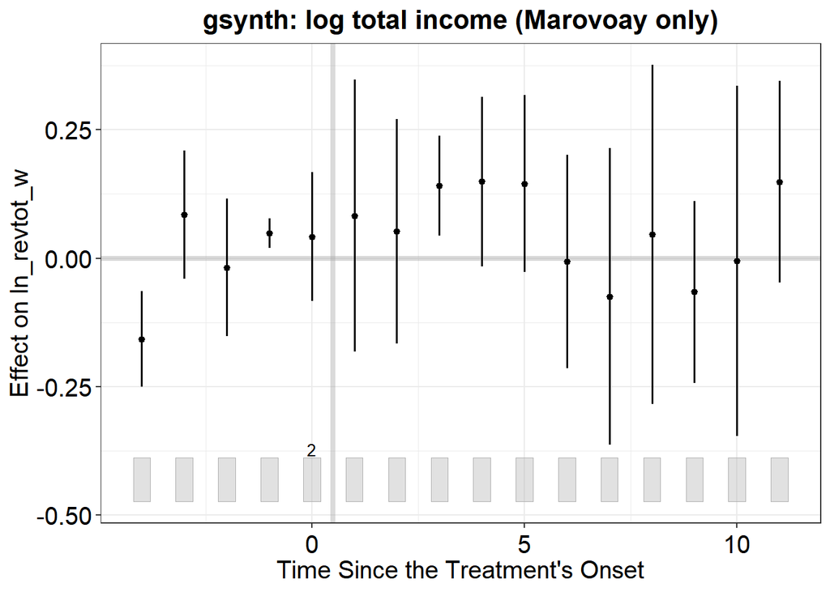

```r
run_gsynth <- function(data, label, r_val = 0, nboots = 200) {
  d <- data |> filter(!is.na(ln_revtot_w))
  sites_ok <- d |>
    filter(year < TREAT_YEAR) |>
    count(site_id) |>
    filter(n >= 4) |>
    pull(site_id)
  d <- d |> filter(site_id %in% sites_ok)

  tryCatch(
    suppressWarnings(
      gsynth(ln_revtot_w ~ treatment,
             data = d, index = c("site_id","year"),
             se = TRUE, inference = "nonparametric", nboots = nboots,
             r = r_val, CV = FALSE, force = "two-way",
             parallel = FALSE, min.T0 = 4, seed = 2139)
    ),
    error = function(e) {
      message("gsynth failed for ", label, ": ", conditionMessage(e))
      NULL
    }
  )
}

gs_maro <- run_gsynth(panel_site_maro,     "Marovoay only")
gs_exp  <- run_gsynth(panel_site_expanded, "Expanded")

if (!is.null(gs_maro))
  plot(gs_maro, type = "gap", main = "gsynth: log total income (Marovoay only)")
```

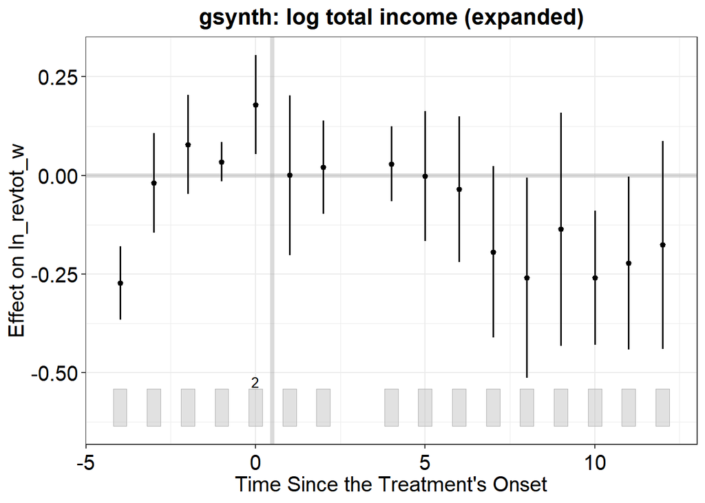

```r
if (!is.null(gs_exp))
  plot(gs_exp, type = "gap", main = "gsynth: log total income (expanded)")
```

## 8 Comparative Results

```r
att_row <- function(method, spec, att, se) {
  tibble(Method = method, Specification = spec, ATT = att, SE = se)
}

# TWFE coefficients
att_twfe_m <- tryCatch(coef(fit_twfe_revtot)[["treatment"]],     error = function(e) NA_real_)
se_twfe_m  <- tryCatch(se(fit_twfe_revtot)[["treatment"]],       error = function(e) NA_real_)
att_twfe_e <- tryCatch(coef(fit_twfe_exp_revtot)[["treatment"]], error = function(e) NA_real_)
se_twfe_e  <- tryCatch(se(fit_twfe_exp_revtot)[["treatment"]],   error = function(e) NA_real_)

# CS-DiD aggregates
att_cs_m <- tryCatch(agg_cs_maro$overall.att, error = function(e) NA_real_)
se_cs_m  <- tryCatch(agg_cs_maro$overall.se,  error = function(e) NA_real_)
att_cs_e <- tryCatch(agg_cs_exp$overall.att,  error = function(e) NA_real_)
se_cs_e  <- tryCatch(agg_cs_exp$overall.se,   error = function(e) NA_real_)

# SDiD
sdid_att_m <- tryCatch(as.numeric(sdid_maro$ln_revtot_w$result$estimate), error = function(e) NA_real_)
sdid_se_m  <- tryCatch(sdid_maro$ln_revtot_w$result$se,                   error = function(e) NA_real_)
sdid_att_e <- tryCatch(as.numeric(sdid_exp$ln_revtot_w$result$estimate),  error = function(e) NA_real_)
sdid_se_e  <- tryCatch(sdid_exp$ln_revtot_w$result$se,                    error = function(e) NA_real_)

# AugSynth
aug_att_m <- tryCatch(summary(aug_maro$ln_revtot_w$result)$average_att$Estimate,  error = function(e) NA_real_)
aug_se_m  <- tryCatch(summary(aug_maro$ln_revtot_w$result)$average_att$Std.Error, error = function(e) NA_real_)
aug_att_e <- tryCatch(summary(aug_exp$ln_revtot_w$result)$average_att$Estimate,   error = function(e) NA_real_)
aug_se_e  <- tryCatch(summary(aug_exp$ln_revtot_w$result)$average_att$Std.Error,  error = function(e) NA_real_)

# gsynth — bootstrap SE from nonparametric inference
gs_att_m <- tryCatch(mean(gs_maro$att.avg, na.rm = TRUE), error = function(e) NA_real_)
gs_att_e <- tryCatch(mean(gs_exp$att.avg,  na.rm = TRUE), error = function(e) NA_real_)
gs_se_m  <- tryCatch(sd(as.vector(gs_maro$att.avg.boot), na.rm = TRUE), error = function(e) NA_real_)
gs_se_e  <- tryCatch(sd(as.vector(gs_exp$att.avg.boot),  na.rm = TRUE), error = function(e) NA_real_)

results_all <- bind_rows(
  att_row("TWFE",           "Marovoay only (4 sites, 4 clusters)",  att_twfe_m, se_twfe_m),
  att_row("TWFE",           "Expanded (9 sites, 9 clusters)",        att_twfe_e, se_twfe_e),
  att_row("CS-DiD",         "Marovoay only",                         att_cs_m,   se_cs_m),
  att_row("CS-DiD",         "Expanded",                              att_cs_e,   se_cs_e),
  att_row("SDiD",           "Marovoay only (2 ctrl)",                sdid_att_m, sdid_se_m),
  att_row("SDiD",           "Expanded (7 ctrl)",                     sdid_att_e, sdid_se_e),
  att_row("AugSynth Ridge", "Marovoay only (2 ctrl)",                aug_att_m,  aug_se_m),
  att_row("AugSynth Ridge", "Expanded (7 ctrl)",                     aug_att_e,  aug_se_e),
  att_row("gsynth",         "Marovoay only",                         gs_att_m,   gs_se_m),
  att_row("gsynth",         "Expanded",                              gs_att_e,   gs_se_e)
) |>
  mutate(
    CI_lo = ATT - 1.96 * SE,
    CI_hi = ATT + 1.96 * SE
  )

gt(results_all) |>
  fmt_number(columns = c(ATT, SE, CI_lo, CI_hi), decimals = 3) |>
  cols_label(Method = "Estimator", Specification = "Specification",
             ATT = "ATT", SE = "SE", CI_lo = "95% CI lo", CI_hi = "95% CI hi") |>
  tab_style(
    style = list(cell_text(weight = "bold"), cell_fill(color = "#DCDCDC")),
    locations = cells_column_labels()
  ) |>
  tab_source_note(
    md("*Outcome*: log winsorised total income. 2005 excluded from all specs.
       gsynth SE via nonparametric bootstrap (200 draws); AugSynth SE via conformal inference (NA when N controls < threshold).")
  )
```

ATT estimates across methods and specifications — log total income

| Estimator | Specification | ATT | SE | 95% CI lo | 95% CI hi |
| --- | --- | --- | --- | --- | --- |
| TWFE | Marovoay only (4 sites, 4 clusters) | 0.034 | 0.149 | −0.258 | 0.326 |
| TWFE | Expanded (9 sites, 9 clusters) | −0.147 | 0.091 | −0.326 | 0.031 |
| CS-DiD | Marovoay only | 0.006 | 0.057 | −0.106 | 0.117 |
| CS-DiD | Expanded | −0.457 | 0.049 | −0.553 | −0.360 |
| AugSynth Ridge | Marovoay only (2 ctrl) | −0.095 | NA | NA | NA |
| AugSynth Ridge | Expanded (7 ctrl) | NA | NA | NA | NA |
| gsynth | Marovoay only | 0.056 | 0.109 | −0.158 | 0.270 |
| gsynth | Expanded | −0.112 | 0.093 | −0.295 | 0.071 |

*Outcome*: log winsorised total income. 2005 excluded from all specs. gsynth SE via nonparametric bootstrap (200 draws); AugSynth SE via conformal inference (NA when N controls < threshold).

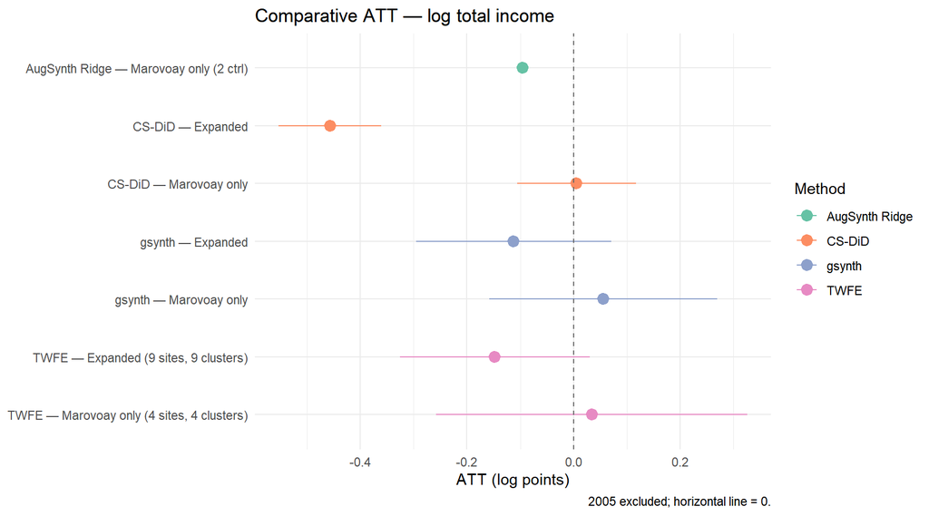

ATT forest plot across methods and specifications

```r
results_all |>
  filter(!is.na(ATT)) |>
  mutate(label = paste0(Method, " — ", Specification)) |>
  ggplot(aes(x = ATT, xmin = CI_lo, xmax = CI_hi,
             y = fct_rev(label), color = Method)) +
  geom_pointrange(na.rm = TRUE, size = 0.7) +
  geom_vline(xintercept = 0, linetype = "dashed", color = "grey40") +
  scale_color_brewer(palette = "Set2") +
  labs(x = "ATT (log points)", y = NULL, color = "Method",
       title = "Comparative ATT — log total income",
       caption = "2005 excluded; horizontal line = 0.") +
  theme_minimal(base_size = 11) +
  theme(legend.position = "right")
```